# Basic Data Visualization in R

Martin Schweinberger

2020-12-05

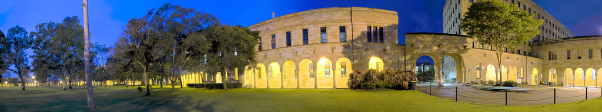

# Introduction

This tutorial introduces different types of data visualization. The entire R-markdown document for the tutorial can be downloaded [here](https://slcladal.github.io/basicgraphs.Rmd). A more in-depth and highly recommendable resource for data visualization in R is Wickham (2016). A more general introduction to data visualization - which is still highly recommendable is Healy (2018).

## Different philosophies: base R, lattice, and ggplot

Before we start, a few words on different frameworks for creating graphics in R are in order. There are three main frameworks in which to create graphics in R. The *basic* framework, the *lattice* framework, and the *ggplot* or *tidyverse* framework. These frameworks reflect the changing nature of R as a programming language (or as a programming environment). The so-called *base R* consists of about 30 packages that are always loaded automatically when you open R - it is, so to say - the default version of using R when nothing else is loaded. The *base R* framework is the oldest way to generate visualizations in R that was used when other packages did not exists yet. However, *base R* can and is still used to create visualizations although most visualizations are now generated using the *ggplot* or *tidyverse* framework. The *lattice* framework followed the *base R* framework and offered some advantages such as handy ways to split up visualizations. However, *lattice* was replaced by the *ggplot* or *tidyverse* framework because the latter are much more flexible, offer full control, and follow an easy to understand syntax.

We will briefly elaborate on these three frameworks before moving on.

### The base R framework

The *base R* framework is the oldest of the three and is included in what is called the `base R` - a collection of about 30 packages that are automatically activated/loaded when you start `R`. The idea behind the “base” environment is that the creation of graphics is seen in analogy to a painter who paints on an empty canvass. Each line or element is added to the graph consecutively which oftentimes leads to code that is very comprehensible but also very long.

### The lattice framework

The *lattice* environment was a follow-up to the *base* framework and it complements it insofar as it made it much easier to display various variables and variable levels simultaneously. The philosophy of the lattice-package is quite different from the philosophy of *base*: whereas everything had to be specified in *base*, the graphs created in the *lattice* environment require only very little code but are therefore very easily created when one is satisfied with the design but vey labor intensive when it comes to customizing graphs. However, *lattice* is very handy when summarizing relationships between multiple variable and variable levels.

### The ggplot framework

The *ggplot* environment was written by Hadley Wickham and it combines the positive aspects of both the *base* and the *lattice* package. It was first publicized in the *gplot* and *ggplot1* packages but the latter was soon repackaged and improved in the now most widely used package for data visualization: the *ggplot2* package. The *ggplot* environment implements a philosophy of graphic design described in builds on *The Grammar of Graphics* by Leland Wilkinson (Wilkinson 2012).

The philosophy of *ggplot2* is to consider graphics as consisting out of basic elements (called *aesthetics* and they include, for instance, the data set to be plotted and the axes) and layers that overlaid onto the aesthetics. The idea of the *ggplot2* package can be summarized as taking “care of many of the fiddly details that make plotting a hassle (like drawing legends) as well as providing a powerful model of graphics that makes it easy to produce complex multi-layered graphics.”

Thus, ggplots typically start with the function call (ggplot) followed by the specification of the data, then the aesthetics (aes), and then a specification of the type of plot that is created (geom_line for line graphs, geom_box for box plots, geom_bar for bar graphs, geom_text for text, etc.). In addition, ggplot allows to specify all elements that the graph consists of (e.g. the theme and axes)

## Preparation and session set up

This tutorial is based on R. If you have not installed R or are new to it, you will find an introduction to and more information how to use R [here](https://slcladal.github.io/IntroR_workshop.html). For this tutorials, we need to install certain *packages* from an R *library* so that the scripts shown below are executed without errors. Before turning to the code below, please install the packages by running the code below this paragraph. If you have already installed the packages mentioned below, then you can skip ahead ignore this section. To install the necessary packages, simply run the following code - it may take some time (between 1 and 5 minutes to install all of the libraries so you do not need to worry if it takes some time).

```r
# install libraries
install.packages(c("knitr", "lattice", "ggplot2", "dplyr",
                   "likert", "scales", "vcd", "tm", "stringr",
                   "SnowballC", "tidyr", "gridExtra", "knitr",
                   "DT", "stringr", "wordcloud"))
```

Once you have installed R, R-Studio, and have also initiated the session by executing the code shown above, you are good to go.

# Getting started

Before turning to the graphs, we will load the packages for this tutorial.

```r
# activate packages
library(knitr)
library(lattice)
library(tidyverse)
library(likert)
library(scales)
library(vcd)
library(tm)
library(SnowballC)
library(gridExtra)
library(knitr)
library(DT)
library(wordcloud)
library(flextable)
```

Also, we will load the data that we will display. The data set is called `lmmdata` but we will change the name to `plotdata` for this tutorial. The data set is based on the [*Penn Parsed Corpora of Historical English*](https://www.ling.upenn.edu/hist-corpora/) (PPC) and it contains the date when a text was written (`Date`), the genre of the text (`Genre`), the name of the text (`Text`), the relative frequency of prepositions in the text (`Prepositions`), and the region in which the text was written (`Region`). We also add two more variables to the data called `GenreRedux` and `DateRedux`. `GenreRedux` collapses the existing genres into five main categories (*Conversational*, *Religious*, *Legal*, *Fiction*, and *NonFiction*) while `DateRedux` collapses the dates when the texts were composed into five main periods (1150-1499, 1500-1599, 1600-1699, 1700-1799, and 1800-1913). We also factorize non-numeric variables.

```r
# load data
plotdata <- read.delim("https://slcladal.github.io/data/lmmdata.txt", header = TRUE) %>%
  mutate(GenreRedux = case_when(str_detect(.$Genre, "Letter") ~ "Conversational",
                                Genre == "Diary" ~ "Conversational",
                                Genre == "Bible"|Genre == "Sermon" ~ "Religious",
                                Genre == "Law"|Genre == "TrialProceeding" ~ "Legal",
                                Genre == "Fiction" ~ "Fiction",
                                TRUE ~ "NonFiction")) %>%
  mutate(DateRedux = case_when(Date < 1500 ~ "1150-1499",
                               Date < 1600 ~ "1500-1599",
                               Date < 1700 ~ "1600-1699",
                               Date < 1800 ~ "1700-1799",
                               TRUE ~ "1800-1913")) %>%
  mutate(Genre = factor(Genre),
         Text = factor(Text),
         Region = factor(Region),
         GenreRedux = factor(GenreRedux),
         DateRedux = factor(DateRedux))
# inspect data
datatable(plotdata, rownames = FALSE, filter="top", options = list(pageLength = 5, scrollX=T))
```

| Date | Genre | Text | Prepositions | Region | GenreRedux | DateRedux |
| --- | --- | --- | --- | --- | --- | --- |
| 1736 | Science | albin | 166.01 | North | NonFiction | 1700-1799 |
| 1711 | Education | anon | 139.86 | North | NonFiction | 1700-1799 |
| 1808 | PrivateLetter | austen | 130.78 | North | Conversational | 1800-1913 |
| 1878 | Education | bain | 151.29 | North | NonFiction | 1800-1913 |
| 1743 | Education | barclay | 145.72 | North | NonFiction | 1700-1799 |
| 1908 | Education | benson | 120.77 | North | NonFiction | 1800-1913 |
| 1906 | Diary | benson | 119.17 | North | Conversational | 1800-1913 |
| 1897 | Philosophy | boethja | 132.96 | North | NonFiction | 1800-1913 |
| 1785 | Philosophy | boethri | 130.49 | North | NonFiction | 1700-1799 |
| 1776 | Diary | boswell | 135.94 | North | Conversational | 1700-1799 |

[output cut: 527 more lines]

In addition, we will create a vector with colors that we will be using throughout this tutorial. This is not really necessary but it shares us from having to specify colors every time when we do not want to use the default colors that R provides. In this case, we will specify five colors but this palette could be extended. You can also check out the colors that are available in R [here](http://www.stat.columbia.edu/~tzheng/files/Rcolor.pdf) and the palettes or sets of colors [here](https://www.datanovia.com/en/blog/top-r-color-palettes-to-know-for-great-data-visualization/).

```r
mycol <- c("indianred4", "gray30", "darkblue", "orange", "gray80")
```

We will now turn to creating the graphs.

# Scatter Plots

The first, and simplest graph, is a so-called *scatterplot*. Scatterplots are used when the graph is set up to display the relationship between two numeric variables. We will start off with creating a scatter plot in *base*, then in *lattice* and finally in the *ggplot* environment.

## Scatter Plots in base

The most fundamental function to create plots in the *base* environment is to use the general “plot” function. Here, we use that function to create a simple scatter plot.

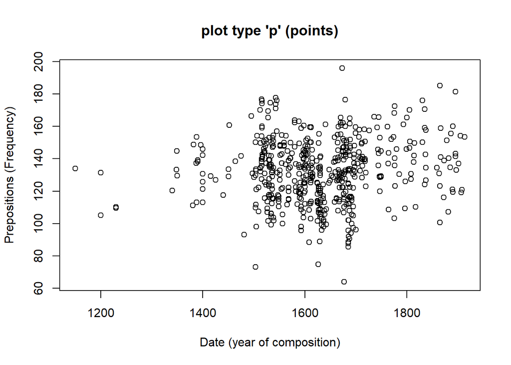

```r
# create simple scatter plot
plot(Prepositions ~ Date,                 # plot Prepositions by Date
     type = "p",                          # plot type p (points)
     data = plotdata,                     # data from data set plotdata
     ylab = "Prepositions (Frequency)",   # add y-axis label
     xlab = "Date (year of composition)", # add x-axis label
     main = "plot type 'p' (points)"      # add title
     )                                    # end drawing plot
```

Let us go over the command. The first part of the call is `plot` which is the function for plotting data in base R. In the round brackets are the arguments in which we specify what the plot should look like. The `Prepositions ~ Date` part tells R which variables should be displayed and the `type = "p"` part tells R which type of plot we want (`p` stands for points, `l` for lines, `b` for both lines and points). The part `data = plotdata` tells R which data set to take the data from, and `ylab = "Prepositions (Frequency)"` and `xlab = "Date (year of composition)"` informs R about the axes’ labels. The part `main = "plot type 'p' (points)"` informs R about what we want as the main title of the plot.

In a next step, we will change the title, add two regression lines to the scatterplot (in the first case a linear and in the second case a smoothed regression line) and we will change the points as well as the color of the points.

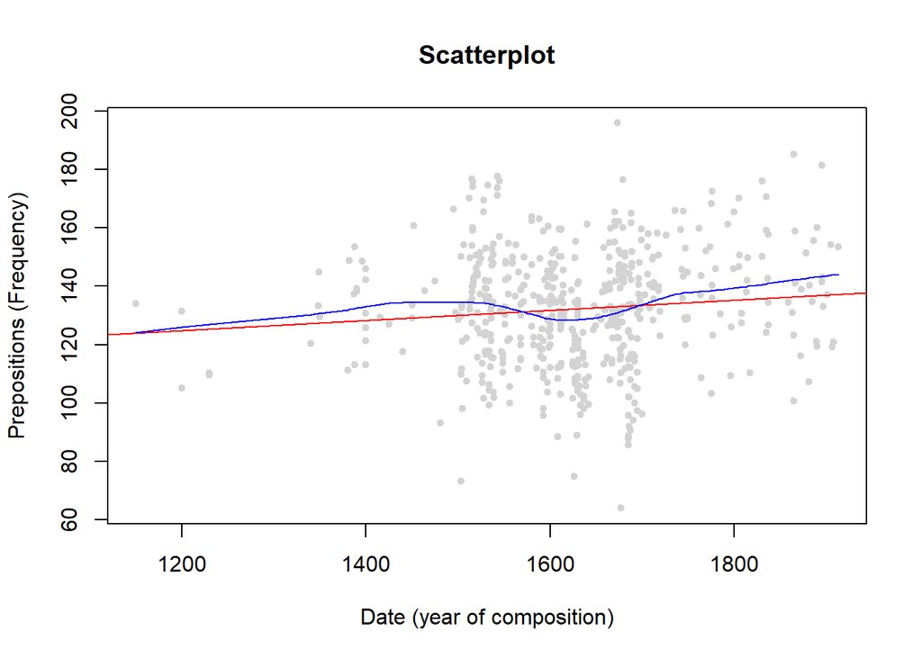

```r
# create simple scatter plot with regression lines (ablines)
plot(Prepositions ~ Date,                 # plot Prepositions by Date
     type = "p",                          # plot type p (points)
     data = plotdata,                     # data from data set iris
     ylab = "Prepositions (Frequency)",   # add y-axis label
     xlab = "Date (year of composition)", # add x-axis label
     main = "Scatterplot",                # add title
     pch = 20,                            # use point symbol 20 (filled circles)
     col = "lightgrey"                    # define symbol colour as light grey
     )                                    # end drawing plot
abline(                                   # add regression line (y~x)
  lm(plotdata$Prepositions ~ plotdata$Date),      # draw regression line of linear model (lm)
  col="red"                               # define line colour as red
  )                                       # end drawing line
lines(                                    # add line (x,y)
  lowess(plotdata$Prepositions ~ plotdata$Date),  # draw smoothed lowess line (x,y)
  col="blue"                              # define line colour as blue
  )                                       # end drawing line
```

The only things that are different in the main call are the “pch” argument with has changed the points into filled dots (this is what the 20 stands for) and the “col” argument which we have specified as “lightgrey”. The regression lines are added using the “abline” and the “lines” argument.

> Exercise Time!

> Load the data set called “data03” and create a simple scatterplot showing the “Variable1” on the x-axis and “Variable2” on the y-axis.

> Tipp: Use the code below to load the data.

```r
# load data03
data03 <- read.delim("https://slcladal.github.io/data/data03.txt", sep = "\t", header = T)
```

The data has the following format:

Overview of data03.

| Variable1 | Variable2 |
| --- | --- |
| 6 | 67 |
| 65 | 16 |
| 12 | 56 |
| 56 | 34 |
| 45 | 54 |
| 84 | 42 |
| 38 | 36 |
| 46 | 47 |
| 64 | 54 |
| 24 | 29 |

## Scatter Plots in lattice

We now turn to data visualization in *lattice*. As the *lattice* package is already loaded, we can create a first simple scatter plot using the “xyplot” function form the “lattice” package. The scatter plot shows the relative frequency of prepositions by year of composition.

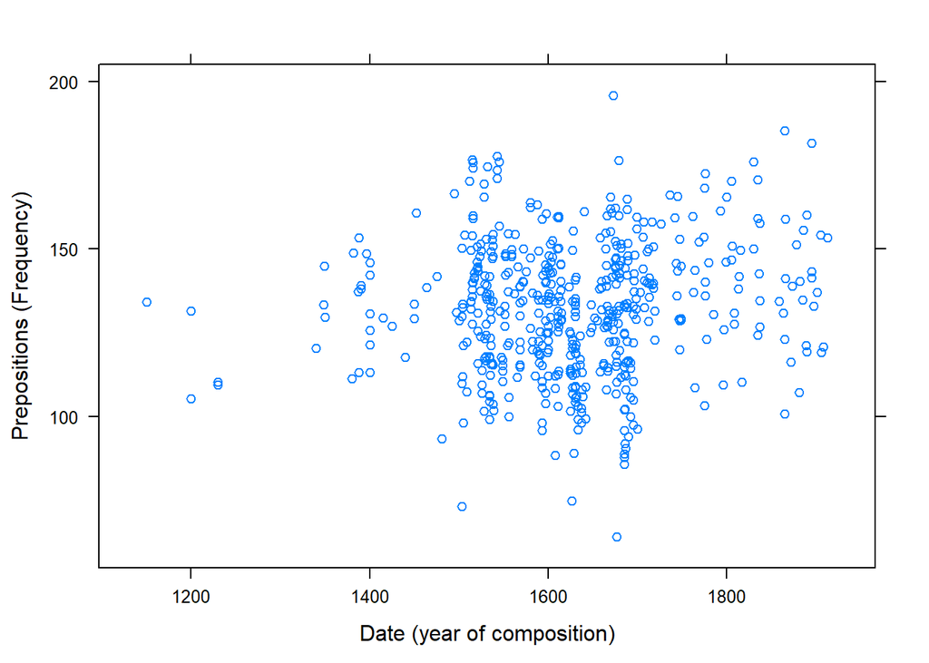

```r
# create simple scatter plot
xyplot(Prepositions ~ Date,
       # add y-axis label
       ylab = "Prepositions (Frequency)",
       # add x-axis label
       xlab = "Date (year of composition)",
       data = plotdata)
```

Since the “lattice” package was created to plot multiple relationships with a single call, we will now make use of that feature and plot multiple relationships at once. In addition, we will add a grid to the plot to improve comparability of data points within the graph. Thus, the scatter plot shows the relative frequency of prepositions by year of composition and genre.

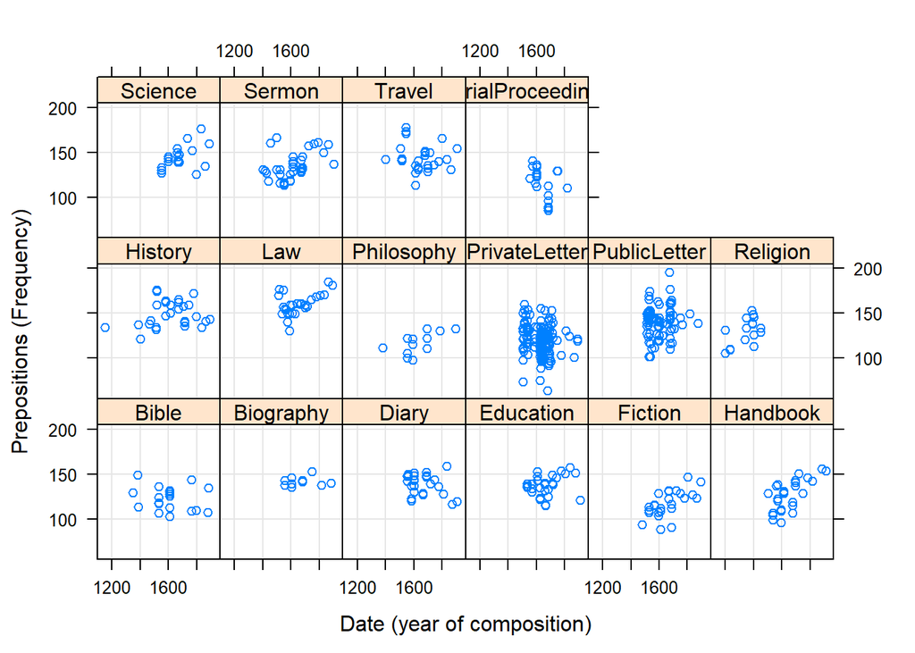

```r
# create scatter plots by species
xyplot(Prepositions ~ Date | Genre,
       # add y-axis label
       ylab = "Prepositions (Frequency)",
       # add y-axis label
       xlab = "Date (year of composition)",
       # add grids to panels
       grid = TRUE,
       data = plotdata
       )
```

The only new code in the chunk above is the “| Genre” part. This part means that the relationship between Prepositions and Date should be displayed by Genre So, the |-symbol can be translated into “by”. The splitting of the plot into different panels for Genre is then done automatically.

Like in base, we can modify lattice-plots and specify, e.g. the symbols that are plotted or their color.

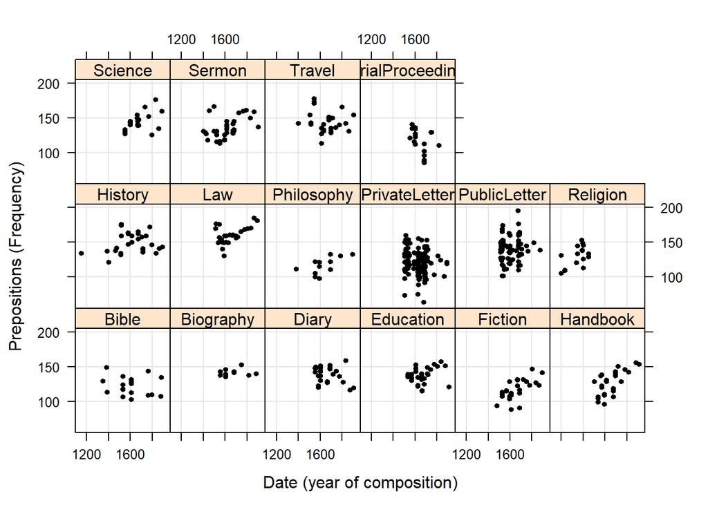

```r
# create scatter plots by species
xyplot(Prepositions ~ Date | Genre,
       ylab = "Prepositions (Frequency)",
       xlab = "Date (year of composition)",
       grid = TRUE,
       # symbol type (20 = filled dots)
       pch = 20,
       # color of symbols
       col = "black",
       data = plotdata
       )
```

Next, we will use the `ggplot2` package to create a scatter plot.

## Scatter Plots in ggplot2

We now turn to data visualization using *ggplot*. As the *ggplot2* package is already loaded, we create a very basic scatterplot in *ggplot2* using the `geom_point` function to show the advantages of creating visualizations in this environment.

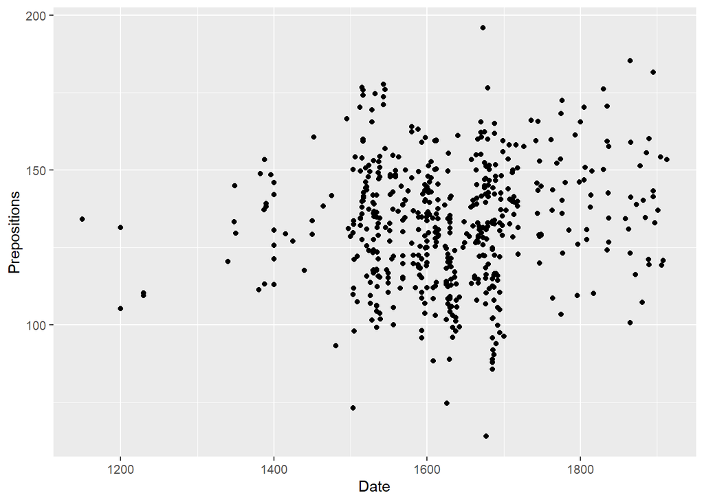

```r
# create simple scatter plot
# use data set "plotdata"
ggplot(plotdata,
       # define axes
       aes(x= Date,
           y= Prepositions)) +
  # define plot type
  geom_point()
```

Let’s go over the code above. The function call for plotting in “ggplot2” is simply “ggplot”. This function takes the data set as its first argument and then requires aesthetics. The aesthetics are defined within the “ggplot” function as the arguments of “aes”. The “aes” function takes the axes as the arguments (in the current case). Then, we need to define the type of plot that we want. As we want a scatter plot with points, we add the “geom_point()” function without any arguments (as we do not want to specify the size, colour, and shape of the points just yet).

The advantage of “ggplot2” is that is really easy to modify the plot by adding new layers and to change the basic outlook by modifying the theme which is what we will do in the code below.

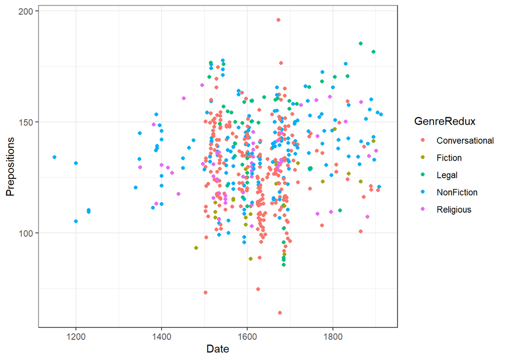

```r
ggplot(plotdata,
       # define axes
       aes(x=Date,
           y= Prepositions,
           # define to color by Species
           color = GenreRedux)) +
  # define plot type
  geom_point() +
  # define theme  as black and white (bw)
  theme_bw()
```

The example above is intended to show that creating ggplots is can be very simple but “ggplot2” is extremely flexible and thus allows us to modify the plot in various ways. To exemplify how a ggplot may be modified, we will change the color of the dots (and use the colors that we have specified earlier), add a white rather than a gray background.

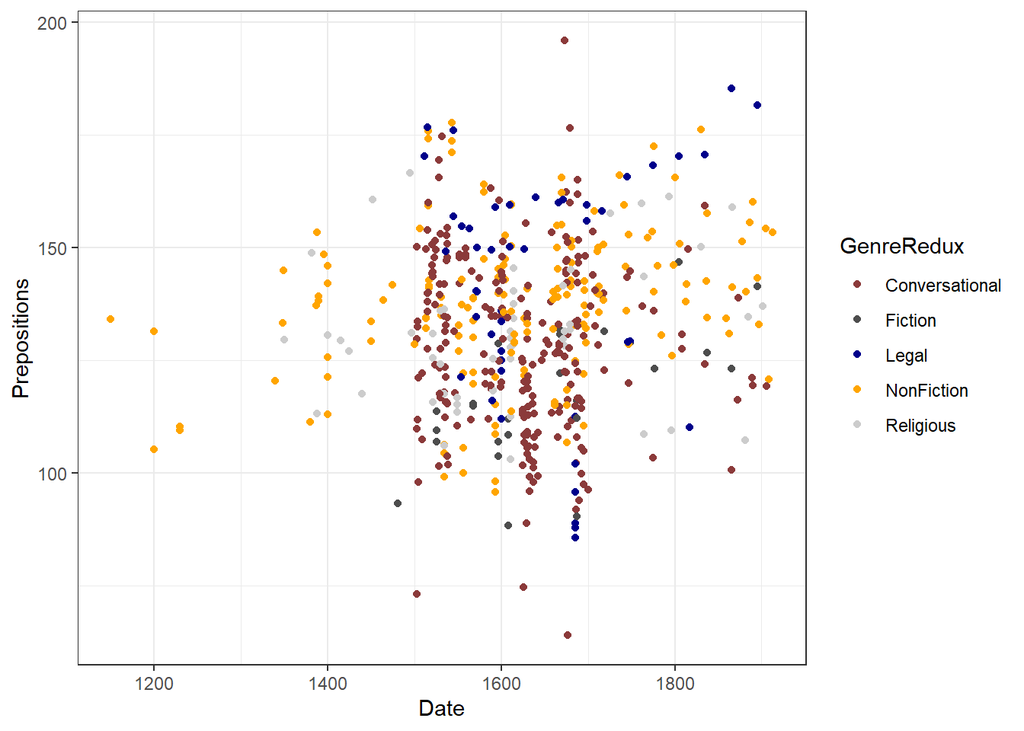

```r
# create scatter plot colored by genre
ggplot(plotdata, aes(x=Date, y= Prepositions, color = GenreRedux)) +
  geom_point() +
  theme_bw() +
  scale_color_manual(values = mycol)
```

The white background is created by specifying the theme as a black and white theme (`theme_bw()`) while the colour of the dots is changed by specifying that the color should be applied by Species (`color = GenreRedux`). Then, the colours to be used are defined in the function `scale_color_manual`.

## Using symbols in scatter plots

We can now specify the symbols in the scatterplot.

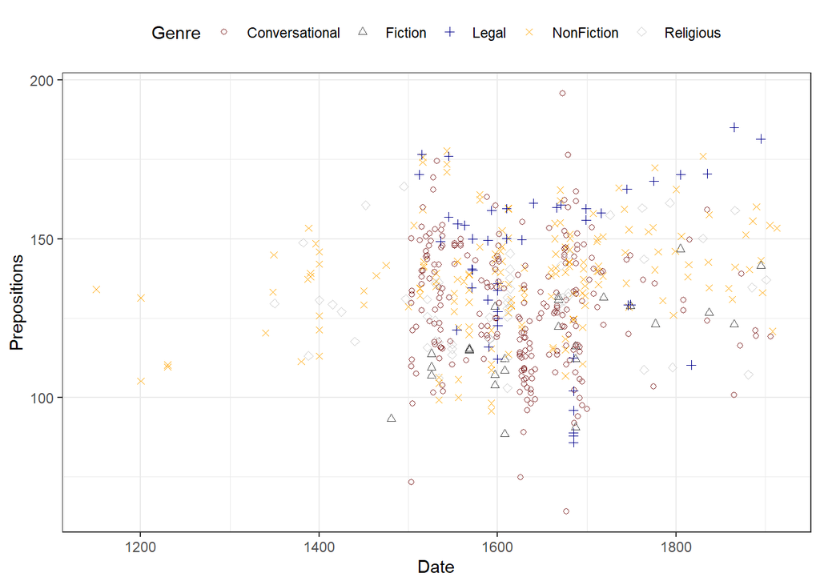

```r
# create scatter plot colored by genre
ggplot(plotdata, aes(Date, Prepositions, color = GenreRedux, shape = GenreRedux)) +
  geom_point() +
  guides(shape=guide_legend(override.aes=list(fill=NA))) +
  scale_shape_manual(name = "Genre",
                     breaks = names(table(plotdata$GenreRedux)),
                     values = 1:5) +
  scale_color_manual(name = "Genre",
                     breaks = names(table(plotdata$GenreRedux)),
                     values = mycol) +
  theme_bw() +
  theme(legend.position="top")
```

## Dot plots with error bars

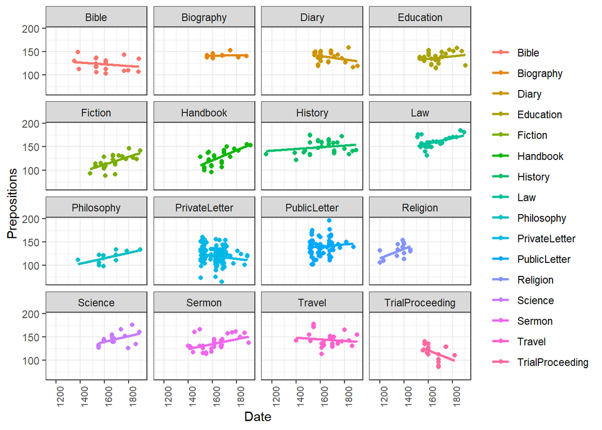

```r
# create scatter plot colored by genre in different panels
ggplot(plotdata, aes(Date, Prepositions,  color = Genre)) +
  facet_wrap(vars(Genre), ncol = 4) +
  geom_point() +
  geom_smooth(method = "lm", se = F) +
  theme_bw() +
  theme(legend.title = element_blank(),
        axis.text.x = element_text(size=8, angle=90))
```

If we only want to show the lines, we simply drop the “geom_point” function.

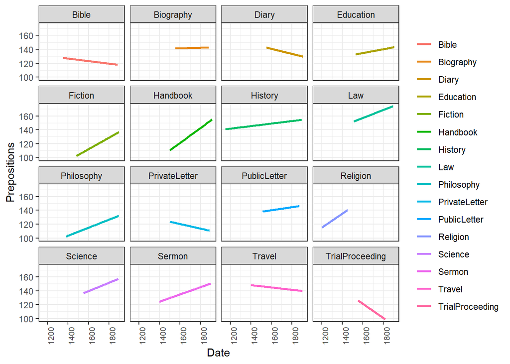

```r
# create scatter plot colored by genre in different panels
ggplot(plotdata, aes(x=Date, y= Prepositions,  color = Genre)) +
  facet_wrap(vars(Genre), ncol = 4) +
  geom_smooth(method = "lm", se = F) +
  theme_bw() +
  theme(legend.title = element_blank(),
        axis.text.x = element_text(size=8, angle=90))
```

Another option is to plot density layers instead of plotting the data points.

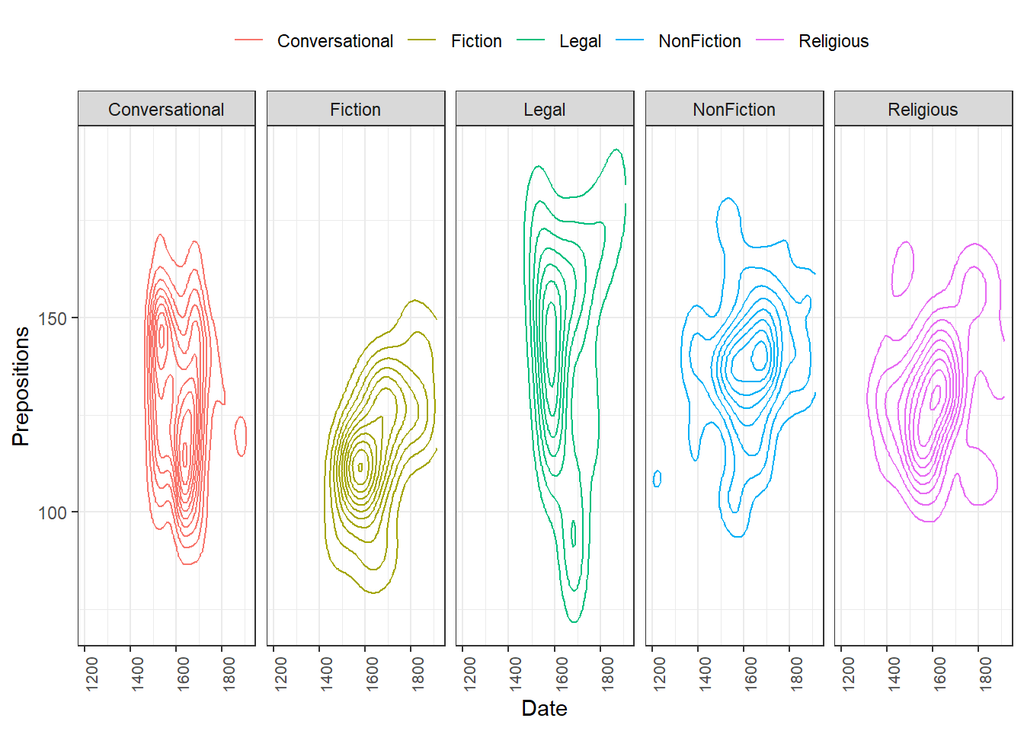

```r
# create scatter density plot
ggplot(plotdata, aes(x=Date, y= Prepositions,  color = GenreRedux)) +
    facet_wrap(vars(GenreRedux), ncol = 5) +
  theme_bw() +
  geom_density_2d() +
  theme(legend.position = "top",
        legend.title = element_blank(),
        axis.text.x = element_text(size=8, angle=90))
```

Although these are not scatterplots, plots with dot-symbols are very flexible and can be extended to show properties of the distribution of values. One way to create such a plot is to plot means as dot-symbols and add error bars to provide information about the underlying distribution. The plot below illustrates such a plot and additionally shows how plots can be further customized.

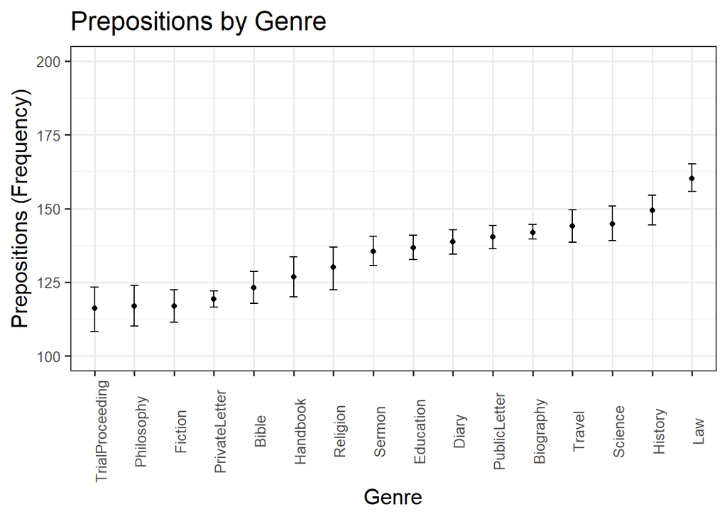

```r
# scatter plot with error bars
ggplot(plotdata, aes(x=reorder(Genre, Prepositions, mean), y= Prepositions,  group = Genre)) +
  # add title
  ggtitle("Prepositions by Genre") +
  # create a dot at means
  stat_summary(fun.y = mean, geom = "point",
               # means by Species
               aes(group= Genre)) +
  # bootstrap data
  stat_summary(fun.data = mean_cl_boot,
               # add error bars
               geom = "errorbar", width = 0.2) +
  # def. y-axis range
  coord_cartesian(ylim = c(100, 200)) +
  # def. font size
  theme_bw(base_size = 15) +
  # def. x- and y-axis
  theme(axis.text.x = element_text(size=10, angle = 90),
        axis.text.y = element_text(size=10, face="plain")) +
  # def. axes labels
  labs(x = "Genre", y = "Prepositions (Frequency)") +
  # def. to col.
  scale_color_manual(guide = FALSE)
```

In the following, we will simply go over the most common types of graphs and use examples to show what they look like and how they can be created. The main graph types we will have a look at are:

- line graphs (“geom_line” and “geom_smooth”)
- bar plots (“geom_bar”)
- boxplots (“geom_box” and “geom_violin”)
- density plots (“geom_density”)

We are now in a position to start creating line graphs with *ggplot*.

# Line Graphs

Line graphs are used when we have numeric values that are linked (in one way or another) because they come from the same speaker or genre as in our case).

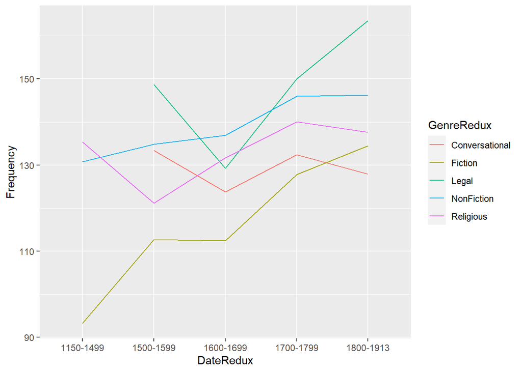

```r
plotdata %>%
  group_by(DateRedux, GenreRedux) %>%
  summarise(Frequency = mean(Prepositions)) %>%
  ggplot(aes(x=DateRedux, y= Frequency, group= GenreRedux, color = GenreRedux)) +
  # add geom layer with lines
  geom_line()
```

## Smoothed line graphs

Another very useful function when creating line graphs with “ggplot” is “geom_smooth” which *smoothes* the lines to be drawn.

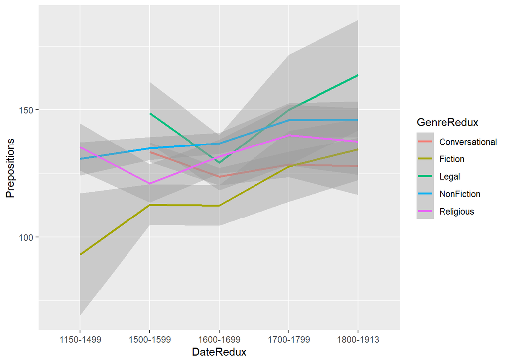

```r
ggplot(plotdata, aes(x=DateRedux, y= Prepositions, group= GenreRedux, color = GenreRedux)) +
  # add geom layer with lines
  geom_smooth()
```

As this smoothed line graph is extremely useful, we will customize it to show how to modify your graph.

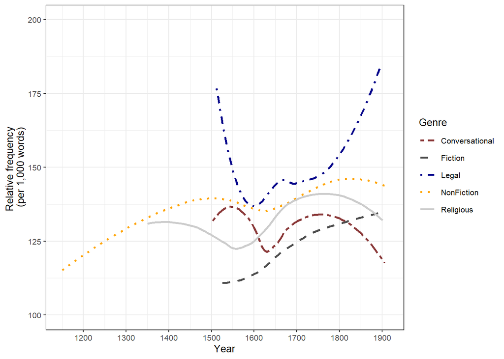

```r
# define aesthetics
ggplot(plotdata, aes(x=Date, y= Prepositions,  color = GenreRedux, linetype = GenreRedux)) +
  # add geom layer with lines
  geom_smooth(se = F) +
  # legend without background color
  guides(color=guide_legend(override.aes=list(fill=NA))) +
  # def. legend position
  theme(legend.position="top") +
  # def. linetype
  scale_linetype_manual(values=c("twodash", "dashed", "dotdash", "dotted", "solid"),
                        # def. legend header
                        name=c("Genre"),
                        # def. linetypes
                        breaks = names(table(plotdata$GenreRedux)),
                        # def. labels
                        labels = names(table(plotdata$GenreRedux))) +
  # def. col.
  scale_colour_manual(values=mycol,
                      # define legend header
                      name=c("Genre"),
                      # define elements
                      breaks=names(table(plotdata$GenreRedux)),
                      # define labels
                      labels = names(table(plotdata$GenreRedux))) +
  # add x-axis label
  labs(x = "Year") +
  # customize x-axis tick positions
  scale_x_continuous(breaks=seq(1100, 1900, 100),
                     # add labels to x-axis tick pos.
                     labels=seq(1100, 1900, 100)) +
  # add y-axis label
  scale_y_continuous(name="Relative frequency \n(per 1,000 words)",
                     # customize tick y-axis
                     limits=c(100, 200)) +
  # define theme  as black and white
  theme_bw(base_size = 10)
```

Although the code for the customized smoothed line graph is much longer and requires addition specifications, it is a very nice way to portrait the development over time.

## Line graphs for Likert data

A special case of line graphs is used when dealing with Likert-scaled variables. In such cases, the line graph displays the density of cumulative frequencies of responses. The difference between the cumulative frequencies of responses displays differences in preferences. We will only focus on how to create such graphs using the “ggplot” environment here as it has an inbuild function (“ecdf”) which is designed to handle such data.

In a first step, we create a data set which consists of a Likert-scaled variable. The fictitious data created here consists of rating of students from three courses about how satisfied they were with their language-learning course. The response to the Likert item is numeric so that “strongly disagree/very dissatisfied” would get the lowest and “strongly agree/very satisfied” the highest numeric value.

```r
likertdata <- read.delim("https://slcladal.github.io/data/likertdata1.txt", header = TRUE)
# inspect data
ft <- flextable(likertdata)
ft <- set_caption(ft,
                  caption = "Overview of the likertdata.")
ft <- autofit(ft)
# inspect data
ft
```

Overview of the likertdata.

| Course | Satisfaction |
| --- | --- |
| Chinese | 1 |
| Chinese | 1 |
| Chinese | 1 |
| Chinese | 1 |
| Chinese | 1 |
| Chinese | 1 |
| Chinese | 1 |
| Chinese | 1 |
| Chinese | 1 |
| Chinese | 1 |
| Chinese | 1 |
| Chinese | 1 |
| Chinese | 1 |
| Chinese | 1 |
| Chinese | 1 |
| Chinese | 1 |
| Chinese | 1 |
| Chinese | 1 |
| Chinese | 1 |
| Chinese | 1 |
| Chinese | 2 |
| Chinese | 2 |
| Chinese | 2 |
| Chinese | 2 |
| Chinese | 2 |
| Chinese | 2 |
| Chinese | 2 |
| Chinese | 2 |
| Chinese | 2 |
| Chinese | 2 |

[output cut: 270 more lines]

Now that we have data resembling a Likert-scaled item from a questionnaire, we will display the data in a cumulative line graph.

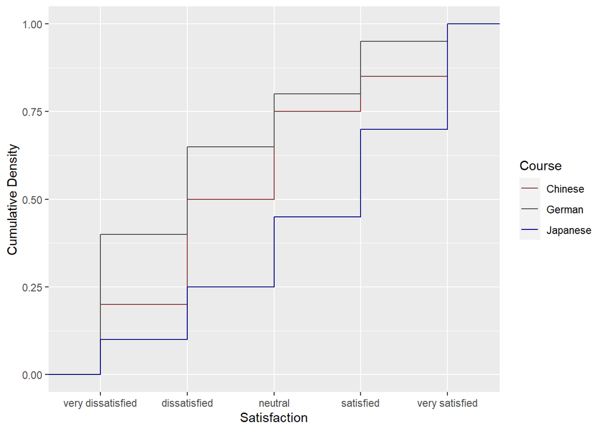

```r
# create cumulative density plot
ggplot(likertdata,aes(x = Satisfaction, color = Course)) +
  geom_step(aes(y = ..y..), stat = "ecdf") +
  labs(y = "Cumulative Density") +
  scale_x_discrete(limits = 1:5, breaks = 1:5,
        labels=c("very dissatisfied", "dissatisfied", "neutral", "satisfied", "very satisfied")) +
  scale_colour_manual(values = mycol)
```

# Pie charts

Most commonly, the data for visualization comes from tables of absolute frequencies associated with a categorical or nominal variable. The default way to visualize such frequency tables are pie charts and bar plots.

In a first step, we modify the original data to get counts and percentages. The data represents the number of documents per time period and the percentage of those documents across all time periods.

```r
# create bar plot data
bardata <- plotdata %>%
  dplyr::mutate(DateRedux = factor(DateRedux)) %>%
  group_by(DateRedux) %>%
  dplyr::summarise(Frequency = n()) %>%
  dplyr::mutate(Percent = round(Frequency/sum(Frequency)*100, 1))
# inspect data
ft <- flextable(bardata)
ft <- set_caption(ft,
                  caption = "Overview of the bardata.")
ft <- autofit(ft)
# inspect data
ft
```

Overview of the bardata.

| DateRedux | Frequency | Percent |
| --- | --- | --- |
| 1150-1499 | 34 | 6.3 |
| 1500-1599 | 180 | 33.5 |
| 1600-1699 | 225 | 41.9 |
| 1700-1799 | 53 | 9.9 |
| 1800-1913 | 45 | 8.4 |

Before creating bar plots, we will briefly turn to pie charts because pie charts are very common despite suffering from certain shortcomings. Consider the following example which highlights some of the issues that arise when using pie charts. In base R, we cerate pie charts using the `pie` function as shown below.

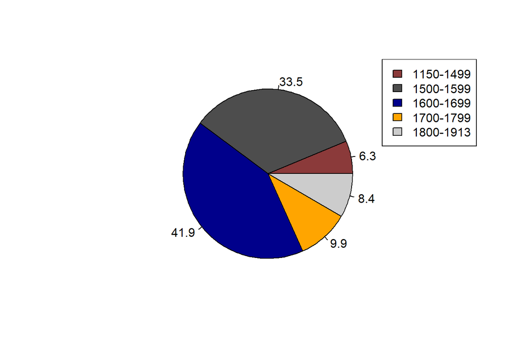

```r
pie(bardata$Percent,
    col = mycol,
    labels = bardata$Percent)
legend("topright", names(table(bardata$DateRedux)),
       fill = mycol)
```

In ggplot, we create pie charts by using the `geom_bar` and then define `coord_polar(“y”, start=0). In contrast to base R, the labeling is not as easy as in base R. We will thus start with a pie chart without labels and then add the labels in a next step.

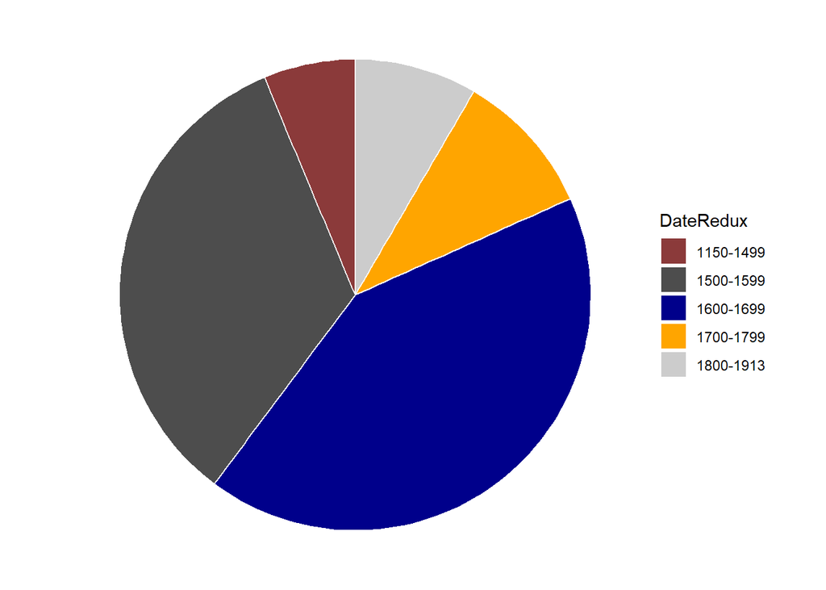

```r
ggplot(bardata,  aes("", Percent, fill = DateRedux)) +
  geom_bar(stat="identity", width=1, color = "white") +
  coord_polar("y", start=0) +
  scale_fill_manual(values = mycol) +
  theme_void()
```

If the slices of the pie chart are not labelled, it is difficult to see which slices are smaller or bigger compared to other slices. This problem can easily be avoided when using a bar plot instead.

The labelling of pie charts is, however, somewhat tedious as the positioning is tricky. Below is an example for adding labels without specification.

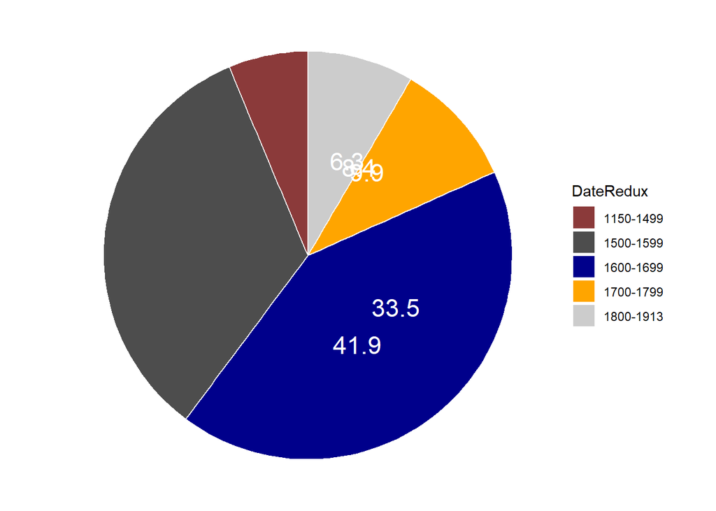

```r
# create pie chart
ggplot(bardata,  aes("", Percent, fill = DateRedux)) +
  geom_bar(stat="identity", width=1, color = "white") +
  coord_polar("y", start=0) +
  scale_fill_manual(values = mycol) +
  theme_void() +
  geom_text(aes(y = Percent, label = Percent), color = "white", size=6)
```

To place the labels where they make sense, we will add another variable to the data called “Position”.

```r
piedata <- bardata %>%
  dplyr::arrange(desc(DateRedux)) %>%
  dplyr::mutate(Position = cumsum(Percent)- 0.5*Percent)
# inspect data
datatable(piedata, rownames = FALSE, filter="top", options = list(pageLength = 5, scrollX=T))
```

| DateRedux | Frequency | Percent | Position |
| --- | --- | --- | --- |
| 1800-1913 | 45 | 8.4 | 4.2 |
| 1700-1799 | 53 | 9.9 | 13.35 |
| 1600-1699 | 225 | 41.9 | 39.25 |
| 1500-1599 | 180 | 33.5 | 76.95 |
| 1150-1499 | 34 | 6.3 | 96.85 |

Now that we have specified the position, we can include it into the pie chart.

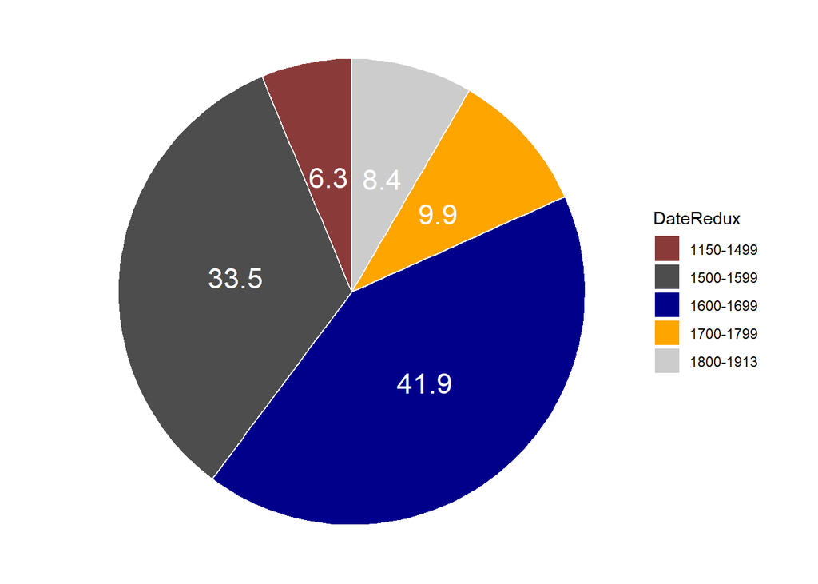

```r
# create pie chart
ggplot(piedata,  aes("", Percent, fill = DateRedux)) +
  geom_bar(stat="identity", width=1, color = "white") +
  coord_polar("y", start=0) +
  scale_fill_manual(values = mycol) +
  theme_void() +
  geom_text(aes(y = Position, label = Percent), color = "white", size=6)
```

# Bar plots

Like pie charts, bar plot display frequency information across categorical variable levels.

## Bar plots in base R

In base R, we use the `barplot` function to create barplots. The `barplot` function is very flexible but takes a table with frequency counts as its main argument. We can also specify axes labels, a title, the color of the bras, and the axes limits. We specify text, grids, and boxes separately after the `barplot` function call.

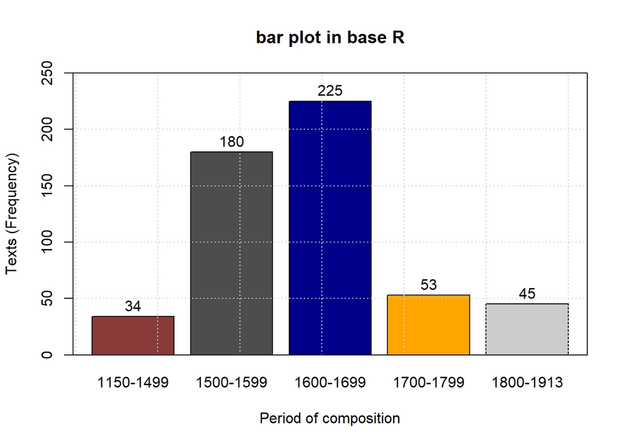

```r
# create simple scatter plot
barplot(table(plotdata$DateRedux),        # plot Texts by DateRedux
     ylab = "Texts (Frequency)",          # add y-axis label
     xlab = "Period of composition",      # add x-axis label
     main = "bar plot in base R",         # add title
     col = mycol,                         # add colors
     ylim = c(0, 250)                     # define y-axis limits
     )                                    # end drawing plot
grid()                                    # add grid
text(seq(0.7, 5.5, 1.2),                  # add label positions (x-axis)
     table(plotdata$DateRedux)+10,        # add label positions (y-axis)
     table(plotdata$DateRedux))           # add labels
box()                                     # add box
```

To create grouped bar plots, we tabulate the variables that we are interested in. In the this example, we group by Region as shown below.

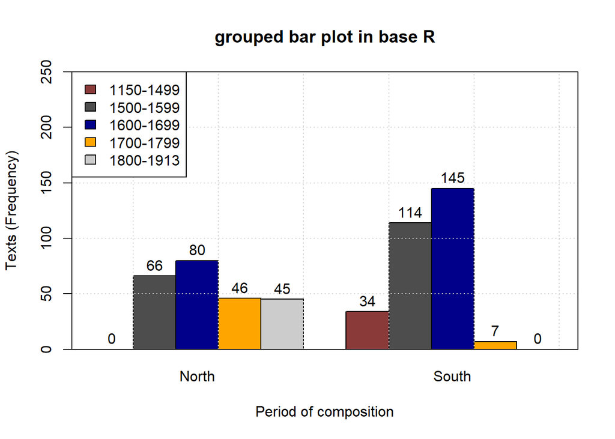

```r
# create simple scatter plot
barplot(table(plotdata$DateRedux, plotdata$Region), # plot Texts by DateRedux
        beside = T,                          # bars beside each other
        ylab = "Texts (Frequency)",          # add y-axis label
        xlab = "Period of composition",      # add x-axis label
        main = "grouped bar plot in base R", # add title
        col = mycol,                         # add colors
        ylim = c(0, 250)                     # define y-axis limits
        )                                    # end drawing plot
grid()                                       # add grid
text(c(seq(1.5, 5.5, 1.0), seq(7.5, 11.5, 1.0)),    # add label positions (x-axis)
     table(plotdata$DateRedux, plotdata$Region)+10, # add label positions (y-axis)
     table(plotdata$DateRedux, plotdata$Region))    # add labels
legend("topleft", names(table(plotdata$DateRedux)), # add legend
       fill = mycol)                        # add colors
box()                                       # add box
```

To transpose the plot, i.e. showing the Frequencies on the x- rather than the y-axis, we set the argument `horiz` to `TRUE`.

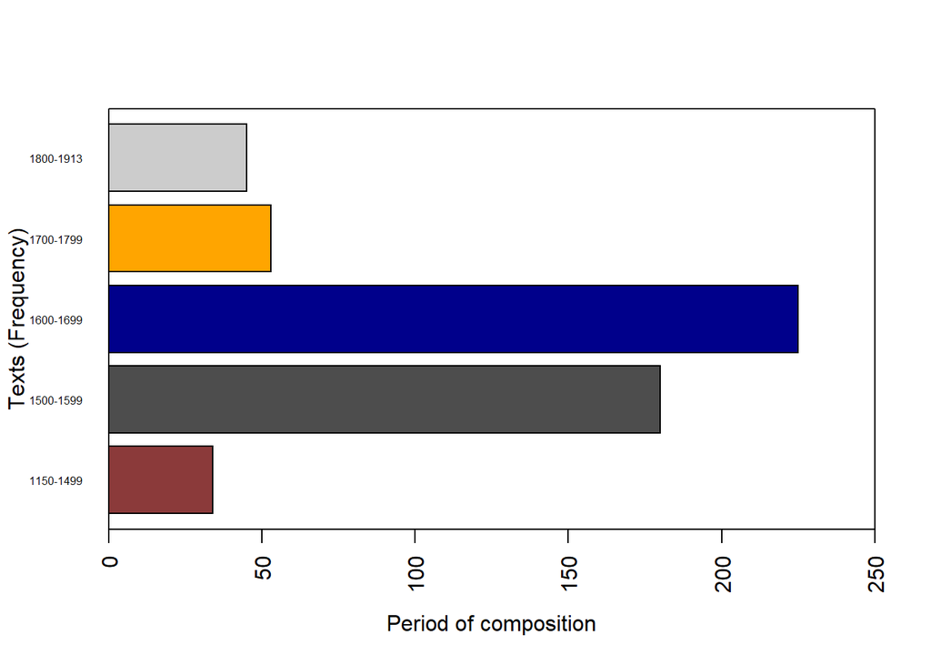

```r
# create simple scatter plot
barplot(table(plotdata$DateRedux),        # plot Texts by DateRedux
     ylab = "Texts (Frequency)",          # add y-axis label
     xlab = "Period of composition",      # add x-axis label
     col = mycol,                         # add colors
     horiz = T,                           # horizontal bars
     xlim = c(0, 250),                    # define x-axis limits
     las = 2,                             # change direction of axis labels
     cex.names = .5)                      # reduce font of axis labels
box()                                     # add box
```

## Bar plots in ggplot

The creation of barplots in ggplot works just like other types of visualizations in this framework. We first define the data and the aesthetics and then use the `geom_bar` to create a barplot.

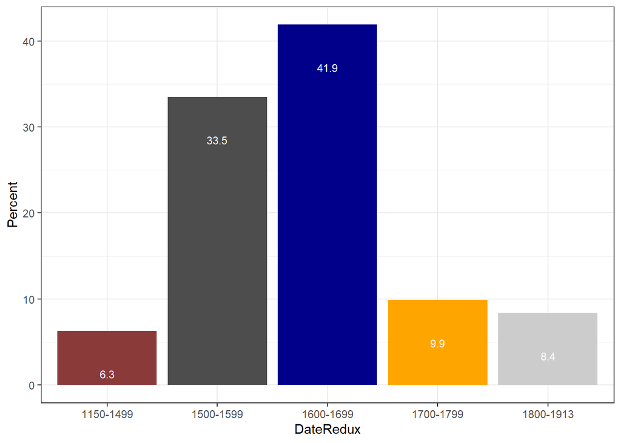

```r
# bar plot
ggplot(bardata, aes(DateRedux, Percent, fill = DateRedux)) +
  geom_bar(stat="identity") +          # determine type of plot
  theme_bw() +                         # use black & white theme
  # add and define text
  geom_text(aes(y = Percent-5, label = Percent), color = "white", size=3) +
  # add colors
  scale_fill_manual(values = mycol) +
  # supress legend
  theme(legend.position="none")
```

Compared with the pie chart, it is much easier to grasp the relative size and order of the percentage values which shows that pie charts are unfit to show relationships between elements in a graph and, as a general rule of thumb, should be avoided.

Bar plot can be grouped to add another layer of information which is particularly useful when dealing with frequency counts across multiple categorical variables. To create grouped bar plots, we plot `Region` while including `DateRedux` as the `fill` argument. Also, we use the command `position=position_dodge()`.

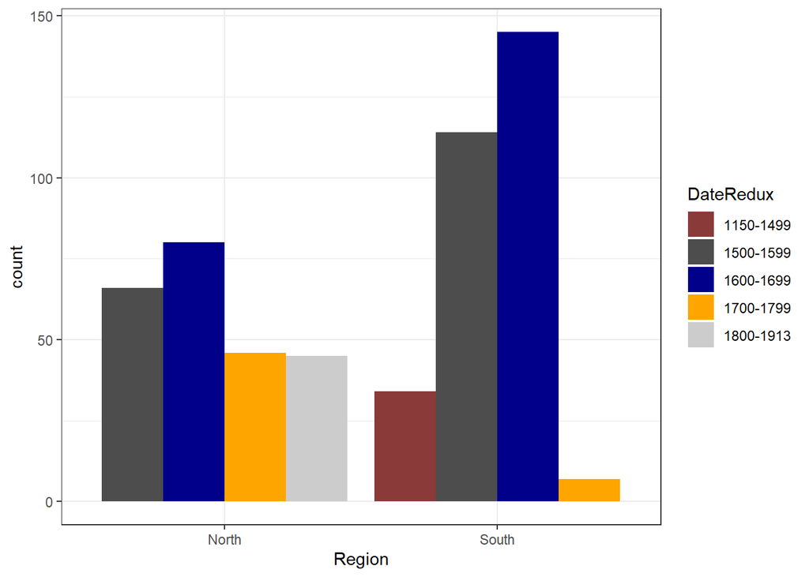

```r
# bar plot
ggplot(plotdata, aes(Region, fill = DateRedux)) +
  geom_bar(position = position_dodge(), stat = "count") +
  theme_bw() +
  scale_fill_manual(values = mycol)
```

If we leave out the `position=position_dodge()` argument, we get a stacked bar plot as shown below.

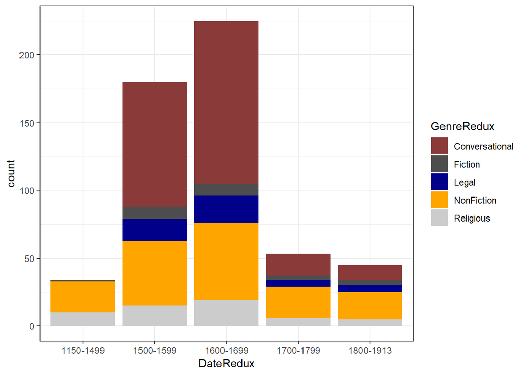

```r
# bar plot
ggplot(plotdata, aes(DateRedux, fill = GenreRedux)) +
  geom_bar(stat="count") +
  theme_bw() +
  scale_fill_manual(values = mycol)
```

One issue to consider when using stacked bar plots is the number of variable levels: when dealing with many variable levels, stacked bar plots tend to become rather confusing. This can be solved by either collapsing infrequent variable levels or choose a colour palette that reflects some other inherent piece of information such as *formality* (e.g. blue) versus *informality* (e.g. red).

Stacked bar plots can also be normalized so that changes in percentages become visible. This is done by exchanging `position=position_dodge()` with `position="fill"`.

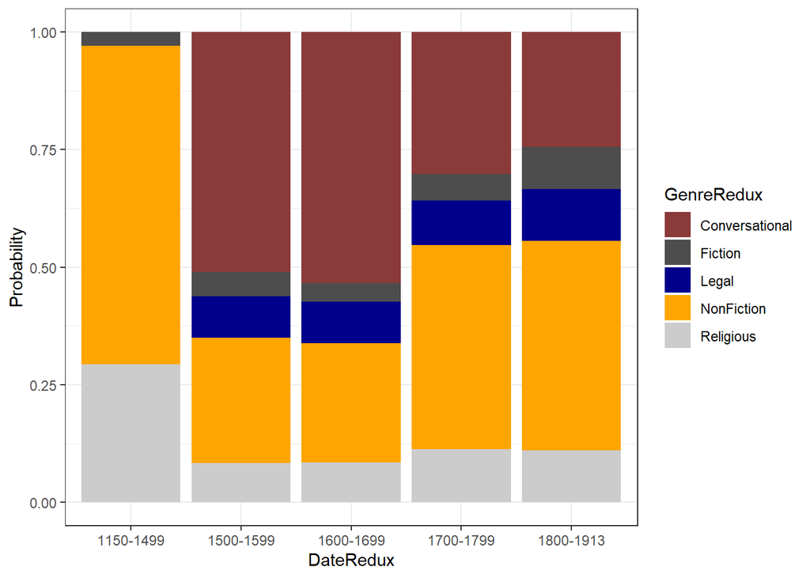

```r
# bar plot
ggplot(plotdata, aes(DateRedux, fill = GenreRedux)) +
  geom_bar(stat="count", position="fill") +
  theme_bw() +
  scale_fill_manual(values = mycol) +
  labs(y = "Probability")
```

## Bar plots for Likert data

Bar plots are particularly useful when visualizing data obtained through Likert items. As this is a very common issue that empirical researchers face. There are two basic ways to display Likert items using bar plots: grouped bar plots and more elaborate scaled bar plots.

Although we have seen above how to create grouped bar plots, we will repeat it here with the language course example used above when we used cumulative density line graphs to visualise how to display Likert data.

In a first step, we recreate the data set which we have used above. The data set consists of a Likert-scaled variable (Satisfaction) which represents rating of students from three courses about how satisfied they were with their language-learning course. The response to the Likert item is numeric so that “strongly disagree/very dissatisfied” would get the lowest and “strongly agree/very satisfied” the highest numeric value.

```r
# create likert data
newlikertdata <- likertdata %>%
  group_by(Course, Satisfaction) %>%
  mutate(Frequency = n())
newlikertdata <- unique(newlikertdata)
# inspect data
head(newlikertdata)
```

```
## # A tibble: 6 x 3
## # Groups:   Course, Satisfaction [6]
##   Course  Satisfaction Frequency
##   <chr>          <int>     <int>
## 1 Chinese            1        20
## 2 Chinese            2        30
## 3 Chinese            3        25
## 4 Chinese            4        10
## 5 Chinese            5        15
## 6 German             1        40
```

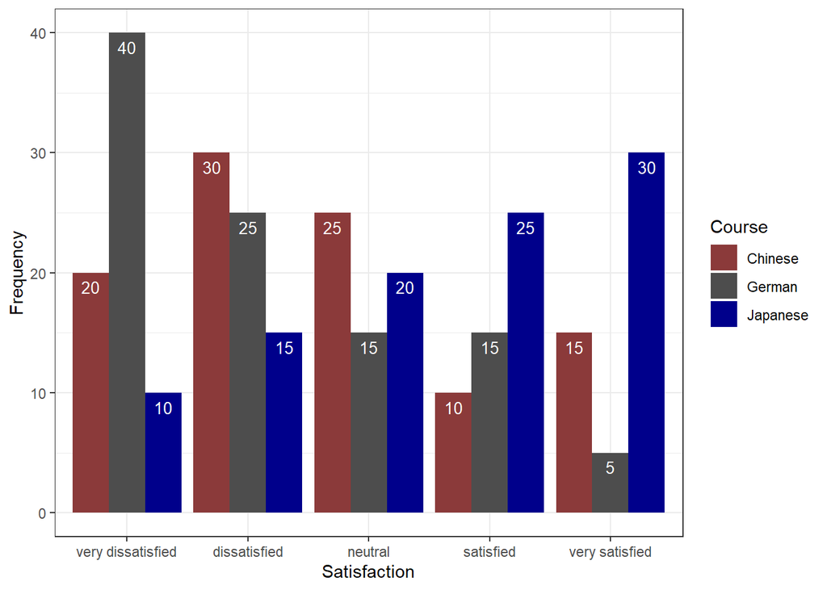

```r
# create grouped bar plot
ggplot(newlikertdata, aes(Satisfaction, Frequency,  fill = Course)) +
  geom_bar(stat="identity", position=position_dodge()) +
  # define colors
  scale_fill_manual(values=mycol) +
  # add text and define colour
  geom_text(aes(label=Frequency), vjust=1.6, color="white",
            # define text position and size
            position = position_dodge(0.9),  size=3.5) +
    scale_x_discrete(limits=c("1","2","3","4","5"), breaks=c(1,2,3,4,5),
        labels=c("very dissatisfied", "dissatisfied",  "neutral", "satisfied",
                 "very satisfied")) +
  theme_bw()
```

Another and very interesting way to display such data is by using the Likert package. In a first step, we need to activate the package, clean the data, and extract a subset for the data visualization example.

```r
# load data
data(pisaitems)           # use a provided dataset called pisaitems
# extract subset from data for visualization
items28 <- pisaitems[, substr(names(pisaitems), 1, 5) == "ST24Q"]
# transform into a likert object
questionl28 <- likert(items28)
# summarize data
summary(questionl28)
```

[output not shown]

After extracting a sample of the data, we plot it to show how the Likert data can be displayed.

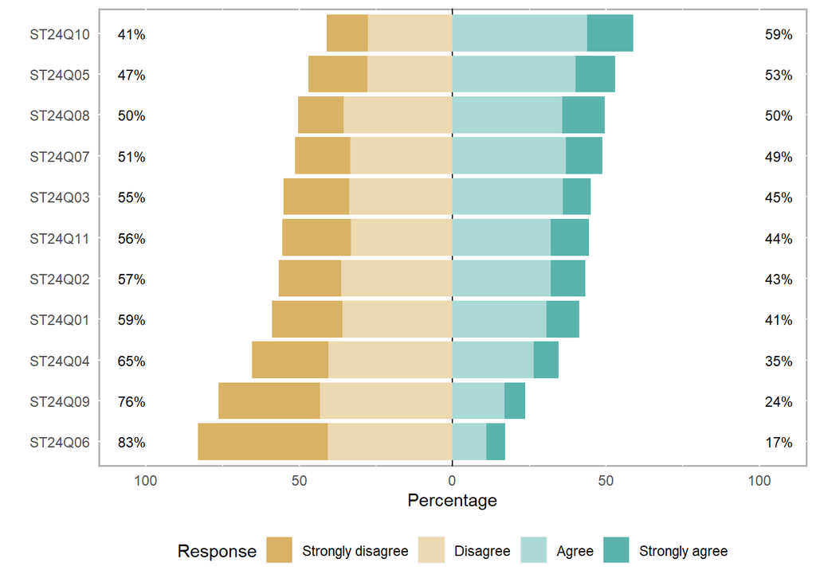

```r
# plot likert data
plot(questionl28)
```

## Comparative bar plots with negative values

Another frequent task is to evaluate the divergence of values from a reference, for instance when dealing with language learners where native speakers serve as a reference or target. To illustrate how such data can be visualized, we load the scales package as we want to create a bar plot in which we show the divergence of learners from native speakers regarding certain features and how that divergence changes over time. Then, we create an example data set which mirrors the format we expect for the actual data.

```r
# create a vector with values called Test1
Test1 <- c(11.2, 13.5, 200, 185, 1.3, 3.5)
# create a vector with values called Test2
Test2 <- c(12.2, 14.7, 210, 175, 1.9, 3.0)
# create a vector with values called Test3
Test3 <- c(13.2, 15.1, 177, 173, 2.4, 2.9)
# combine vectors in a data frame
testdata <- data.frame(Test1, Test2, Test3)
# add rownames
rownames(testdata) <- c("Feature1_Student",
                        "Feature1_Reference",
                        "Feature2_Student",
                        "Feature2_Reference",
                        "Feature3_Student",
                        "Feature3_Reference")
# inspect data
testdata
```

[output not shown]

We can now determine how the learners deviate from the native speakers.

```r
# determine divergence from reference
# row 1 (student) minus row 2 (reference)
FeatureA <- t(testdata[1,] - testdata[2,])
# row 3 (student) minus row 4 (reference)
FeatureB <- t(testdata[3,] - testdata[4,])
# row 5 (student) minus row 6 (reference)
FeatureC <- t(testdata[5,] - testdata[6,])
# create data frame
plottable <- data.frame(rep(rownames(FeatureA), 3),
                  c(FeatureA, FeatureB, FeatureC),
                  c(rep("FeatureA", 3),
                    rep("FeatureB", 3),
                    rep("FeatureC", 3)))
# def. col. names
colnames(plottable) <- c("Test", "Value", "Feature")
# inspect data
plottable
```

[output not shown]

Finally, we graphically display the divergence using a bar plot.

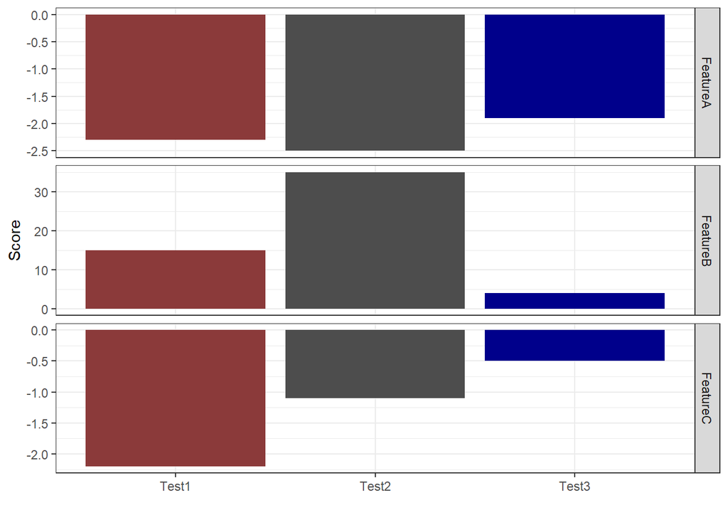

```r
# create plot
ggplot(plottable,
       aes(Test, Value)) + # def. x/y-axes
  # separate plots for each feature
  facet_grid(vars(Feature), scales = "free_y") +
  # create bars
  geom_bar(stat = "identity", aes(fill = Test)) +
  # black and white theme
  theme_bw() +
  # supress legend
  guides(fill=FALSE) +
  # def. colours
  geom_bar(stat="identity", fill=rep(mycol[1:3], 3)) +
  # axes titles
  labs(x = "", y = "Score")
```